# Day 5 · 集成学习——三个臭皮匠顶个诸葛亮

> 目标：理解 Bagging / Boosting 两大流派，手写随机森林思想，对比 XGBoost

> 核心思想：**多个弱模型组合 → 强模型**

```
========================================
Day 5 · 集成学习 Ensemble Learning
========================================
```

## 1. 为什么需要集成？

> 一棵决策树容易过拟合 → 多棵树一起投票，偏差抵消

**直觉类比（C++ 角度）：**

```
// 一颗决策树 = 一个 if-else 专家
if (worst_radius <= 16.8 && mean_concave_points <= 0.05)
    return 良性;

// 随机森林 = 100 个 if-else 专家投票
int votes = 0;
for (auto &tree : forest) {
    votes += tree.predict(sample);  // 每人一票
}
return votes > 50 ? 良性 : 恶性;   // 多数胜出
```

**两大流派：**

| 流派 | 思路 | 代表 | 关键词 |
| --- | --- | --- | --- |
| **Bagging** | 并行训练，投票平均 | 随机森林 | 降低方差、独立 |
| **Boosting** | 串行训练，后一个修正前一个 | AdaBoost, XGBoost | 降低偏差、迭代 |

```
训练集: 455 样本 x 30 特征
测试集: 114 样本
单棵决策树 (max_depth=5) 准确率: 0.9474  <- 基准
```

## 2. Bagging —— Bootstrap Aggregating

> 同一个算法，不同数据子集 → 并行训练 → 投票

**三步走：**

1. **Bootstrap 采样**：从训练集有放回地抽 N 个子集（每个子集约 63% 原数据）
2. **独立训练**：每个子集训一棵树（并行！）
3. **投票聚合**：所有树投票，多数胜出

**为什么有效？** 每棵树看到的数据不同 → 学到的东西不同 → 错误方向也不同 → 平均后抵消

```
手写 Bagging (50棵树) 准确率: 0.9561
单棵决策树 准确率:              0.9474
提升: +0.0088
```

```
Bootstrap 抽取 1000 个样本
不重复的样本: 626 (62.6%)
没抽到的 (OOB): 374 (37.4%)
结论: 每棵树只看到 ~63% 的数据，37% 是天然验证集 (OOB)
```

## 3. 随机森林 —— Bagging + 特征随机

> 随机森林 = Bagging + **随机选特征**

Bagging 只随机了样本，随机森林连特征也随机：

> 每次分裂时，不是从所有特征里选最优，而是**随机抽 sqrt(d) 个特征**，从中选最优

**这有什么用？** 防止某几个强特征"统治"所有树 → 树之间更不相关 → 方差更低

```
Bagging:       每棵树看到的 样本 不同
Random Forest: 每棵树看到的 样本 不同 + 特征 不同  <- 更强的随机性
```

```
随机森林 (100棵树, max_depth=5) 准确率: 0.9649
单棵决策树 准确率:                      0.9474
手写 Bagging 准确率:                    0.9561
随机森林 vs Bagging: +0.0088 <- 特征随机的好处
```

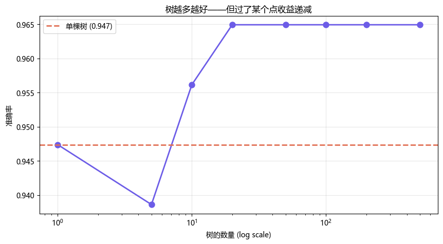

```
1棵树:  0.9474
100棵树: 0.9649
500棵树: 0.9649
结论: 过了 ~50-100 棵树之后基本持平 → 收益递减
```

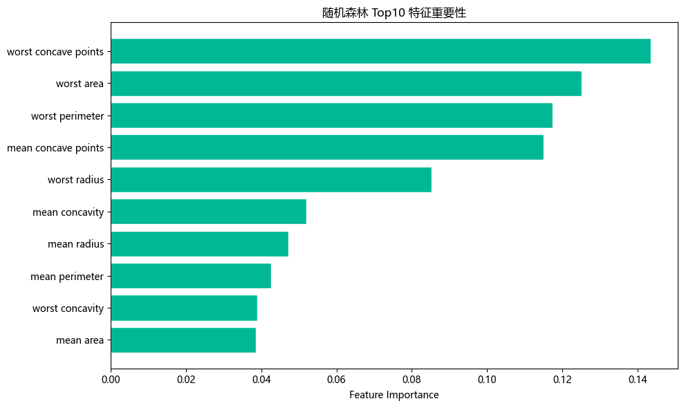

## 4. Boosting —— 知错就改，逐步加强

> Bagging 是"各自为政"→ 投票；Boosting 是"师徒传承"→ 后面补前面

**核心思想：**

1. 训一棵弱树（很浅，故意欠拟合）
2. 看哪些样本错了 → **加大它们的权重**
3. 训下一棵树，重点关注上次错的样本
4. 重复 → 最终加权投票

```
Bagging:  树1 树2 树3 ... 树10  (并行，互不影响)
Boosting: 树1 → 树2 → 树3 → ... → 树10 (串行，后一棵依赖前一棵)
```

```
手写 AdaBoost (50轮) 准确率: 0.9649
单棵决策树 准确率:            0.9474
随机森林 准确率:              0.9649
```

```
==================================================
单棵决策树 (max_depth=5):     0.9474
Bagging (手写, 50棵):        0.9561
随机森林 (100棵):            0.9649
AdaBoost (sklearn, 100轮):   0.9737
Gradient Boosting (100轮):   0.9561
==================================================
```

## 5. XGBoost —— 工业界的 Boosting 天花板

> Kaggle 竞赛的神器。为什么 XGBoost 这么强？

| 优化点 | 为什么重要 |
| --- | --- |
| **二阶导数** | GB 只用一阶梯度（方向），XGB 用二阶（方向 + 步长） |
| **正则化** | 加了 L1/L2 惩罚项，防止过拟合 |
| **列采样** | 和随机森林一样随机选特征 |
| **Shrinkage** | learning_rate 缩小每步贡献，慢慢来 |
| **并行** | 训练阶段可以并行算特征分裂点 |

[output not shown]

[figure not shown]

[output not shown]

## 6. 可视化对比——用一个非线性数据集直观感受

> 用 make_moons 生成两个半月形，看各个算法的决策边界

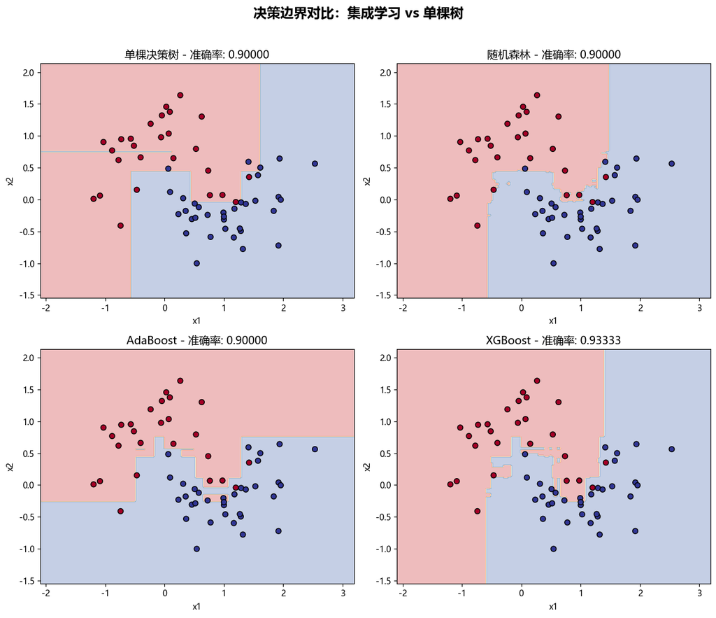

[output not shown]

## 7. Bagging vs Boosting —— 终极对比

| 维度 | Bagging (随机森林) | Boosting (XGBoost) |
| --- | --- | --- |
| **训练方式** | 并行 | 串行（后一棵依赖前一棵） |
| **主要降低** | 方差（过拟合） | 偏差（欠拟合） |
| **基学习器** | 强学习器（深树） | 弱学习器（浅树，stump） |
| **对噪声** | 不敏感（平均掉了） | 敏感（会追着噪声学） |
| **样本权重** | 每轮一样 | 错分样本权重加大 |
| **GPU 加速** | 天然并行 | XGBoost/LightGBM 支持 |
| **调参难度** | 低（主要调 n_estimators） | 高（lr + depth + n_estimators 联动） |
| **经典场景** | 特征维度高、数据噪声大 | 结构化数据、表格数据竞赛 |

**一句话选型：**

> 数据干净、想做表格数据竞赛 → XGBoost / LightGBM 数据噪声大、想快速出结果 → 随机森林

```
=======================================================
  Day 5 最终结果 —— 乳腺癌数据集
=======================================================
  单棵决策树                0.947368 #####################################
  Bagging (手写)         0.956140 ######################################
  随机森林                 0.964912 ######################################
  AdaBoost (手写)        0.964912 ######################################
  Gradient Boosting    0.956140 ######################################
  XGBoost              0.956140 ######################################
=======================================================
  最佳: 随机森林 (0.964912)
  单棵树 -> 随机森林 提升: +0.017544
```

## 8. 拓展：LightGBM & CatBoost（了解）

> XGBoost 之后的两大玩家：

| 框架 | 核心改进 | 什么时候用 |
| --- | --- | --- |
| **LightGBM** | Leaf-wise 生长 + GOSS 采样 | 大数据集（百万级），更快 |
| **CatBoost** | 原生处理类别特征，不需要手动 One-Hot | 类别特征多的表格数据 |
| **XGBoost** | 经典稳健，生态最好 | 大多数情况默认首选 |

# Day 5 完成！

## 今天学到的

| 概念 | 一句话 |
| --- | --- |
| **集成学习** | 多个弱模型组合 -> 强模型 |
| **Bagging** | Bootstrap 采样 + 并行训练 + 投票 |
| **随机森林** | Bagging + 特征随机 -> 树之间更不相关 |
| **Boosting** | 串行训练，后一棵修正前一棵的错误 |
| **AdaBoost** | 错分样本权重加大 -> 下一棵重点关注 |
| **Gradient Boosting** | 每次拟合残差（梯度方向） |
| **XGBoost** | GB + 二阶导数 + 正则化 + 并行 -> 工业首选 |

## C++ 角度

```
// Bagging: parallel for — 每棵树独立训练
#pragma omp parallel for
for (int i = 0; i < n_trees; i++)
    trees[i].fit(bootstrap_sample(i));

// Boosting: sequential — 后一棵依赖前一棵
for (int i = 0; i < n_trees; i++) {
    trees[i].fit(X, y, sample_weights);  // 权重上轮更新
    sample_weights = update_weights(trees[i].errors());
}

// 预测: 投票
int votes = 0;
for (auto &tree : forest)
    votes += tree.predict(x);  // {-1, 1}
return votes > 0 ? 1 : -1;
```

## 晚上作业

1. 把随机森林的 n_estimators 从 1 改到 500，画准确率曲线，看拐点在哪
2. 对比 max_depth=3 vs 10 vs None 时随机森林的过拟合情况
3. 预习 K-Means 聚类（Day 6 内容）—— 一个问题：怎么自动分类没有标签的数据？